# Banding processing

LGCarlson

9/15/2020

## Banding codes

*age:*

- 0 unknown
- 1 AHY
- 2 HY
- 3 Juvenile
- 4 Local
- 5 SY
- 6 ASY

*sex:*

- 0 unknown
- 4 M
- 5 F

*b_dir:*

- 0 NW quarter of the earth

*b_flyway:*

- 2 Mississippi
- 3 Central
- 6 Canada

*b_region:*

[codes here](https://www.pwrc.usgs.gov/BBL/MANUAL/reg.cfm#region) Canadian categories to keep: (US Flyways okay)

- 43 Northwest Territories
- 40 Nunavut
- 04 Alberta
- 79 Saskatchewan
- 45 Manitoba
- 68 Ontario

*b_day_code:*

- 0 unknown
- 1 Day 1-5
- 2 Day 6-10
- 3 Day 11-15
- 4 Day 16-20
- 5 Day 21-25
- 6 Day >26

*status:*

- 2 transported
- 3 normal wild
- 4 hand reared
- 5 sick, injured, deformity
- 6,7,8 experimental, etc

*sp_num:*

- 1320 MALL

*ai_vai:*

Categories to keep:

- Federal numbered metal band only.
- Captured by spotlighting.
- Misc. metal band (State, Provincial etc) with address or telephone number, plus Federal band.
- Miscellaneous band, Federal band, plus auxiliary marker(s).

## Setup

```r
theme_set(theme_light())

#set personalized plotting theme
LGCtheme <- theme_light() + theme(panel.background = element_blank(),
                panel.grid = element_blank(),
                axis.text = element_text(size = 13),
                axis.title = element_text(size = 14),
                legend.text = element_text(size = 13),
                legend.title = element_text(size = 14),
                strip.background = element_blank(),
                strip.text = element_text(size = 13, color = "black"))

gmri_qual_extended<-c("#003A54","#00608A","#5D96AF","#3F4B24","#6F7E4B","#97AA5C","#A8B212","#AF9700","#EACA00","#FFE961","#BB3F0E", "#EA4F12","#F4916B","#00736D", "#55A29E","#A0CDCB","#767676","#A7A7A7","#E2E2E2")
```

```r
date_code_tib<-tribble(
  ~b_day_code, ~b_day,
  1, 5,
  2, 10,
  3, 15,
  4, 20,
  5, 25,
  6, 28)


provs_keep<-c(43,40,04,79,45,68)

ai_vai_vec<-c("Federal numbered metal band only.","Captured by spotlighting.", "Misc. metal band (State, Provincial etc) with address or telephone number, plus Federal band.","Miscellaneous band, Federal band, plus auxiliary marker(s).")


b_region_codes<-read_csv(here::here("raw_data", "region_codes.csv")) %>%
  filter(!is.na(region_abbrev)) %>%
  dplyr::select(-region_name,-flyway_code) %>%
  dplyr::rename("b_region" = "region_code","b_region_abbrev" = "region_abbrev")
```

## Load data

*Modifications:*

- remove indv. where banding month is unknown
- remove indv. where banding day is unknown
- join date_code_tib by b_day_code, so that b_day so that approximate banding_dates can be created using maximum dates in b_day_code range
- create a new column with banding date

```r
all_bands<-bind_rows(ca_band, cl_band, ms_band) %>%
  filter(b_month <= 12,
         b_day_code > 0) %>%
  left_join(date_code_tib, by = "b_day_code") %>%
  mutate(b_date = as.Date(paste(b_year,b_month,b_day, sep = "-"))) %>%
  left_join(b_region_codes, by = "b_region")
```

## Check data

```r
table(all_bands$age)
```

```
##
##      0      1      2      3      4      5      6      7      8
##   3664 104461  81959      1  24724   8166   3031     11     21
```

```r
table(all_bands$sex)
```

```
##
##      0      4      5      6      7
##   2694 111275 112043     10     16
```

```r
table(all_bands$b_month)
```

```
##
##      1      2      3      4      5      6      7      8      9     10     11
##  12946  11849   2887   4150   5257   4046  17013 104637  47851   6732   5078
##     12
##   3592
```

```r
table(all_bands$b_day_code)
```

```
##
##     1     2     3     4     5     6
## 31652 37069 39954 39835 38853 38675
```

```r
table(all_bands$status)
```

```
##
##      2      3      4      5      6      7      8
##    510 218231   5666    486     80    903    162
```

```r
table(all_bands$b_region_abbrev)
```

```
##
##    AB    AL    AR    CO    IA    IL    IN    KS    KY    LA    MB    MI    MN
## 23398  1020  3413 13075  3457  4003  1593  1677  1653  2254 11730 14197 17099
##    MO    MS    MT    ND    NE    NM    NT    NU    OH    OK    ON    SD    SK
##  1033  2421  9240  9643  2840  1674  3235    36  6359  1278 35385  6347 27479
##    TN    TX    WI    WY
##  3029  2018 13089  2363
```

```r
#table(all_bands$ai_vai)
```

## Processing code

*Modifications:*

- limit years to 1961-2011
- keep only pre-season banded birds
- keep only normal, wild birds (status)
- keep only known sexes (4,5)
- keep only desired ai_vai’s
- re-order columns manually

```r
final_bands<-all_bands %>%
  filter(b_year >=1961 & b_year <=2011) %>%
  filter(b_month >=6 & b_month <=9) %>%
  filter(status == 3) %>%
  filter(sex == 4 | sex == 5) %>%
  filter(ai_vai %in% ai_vai_vec) %>%
  dplyr::select(band_prefix_plus,count_of_birds,age,age_vage,sex,sp_num,status,b_flyway,b_flyway_name,b_date,b_year,b_month,b_day_code, b_day, country_code,b_region,b_region_abbrev,state_code,b_dir,b_coord_prec,b_lat,b_long,
                gisb_lat,gisb_long, band_size,band_type,ai_vai,how_aged,how_sexed)
```

## Visualize data

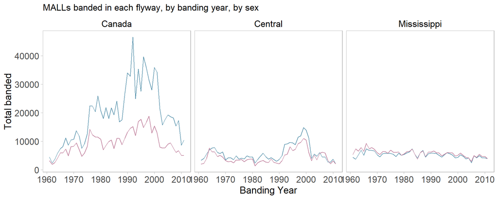

```r
final_bands %>%
  group_by(b_year, sex, b_flyway_name) %>%
  summarise(total_banded = sum(count_of_birds)) %>%
  ggplot(aes(x=b_year, y=total_banded, color=as.factor(sex))) + geom_line() +
  facet_wrap(~b_flyway_name, ncol=3) +
  scale_color_manual(values=c("#5D96AF","#C07F9C")) + LGCtheme + theme(legend.position = "none") +
  labs(x="Banding Year", y="Total banded", title="MALLs banded in each flyway, by banding year, by sex")
```

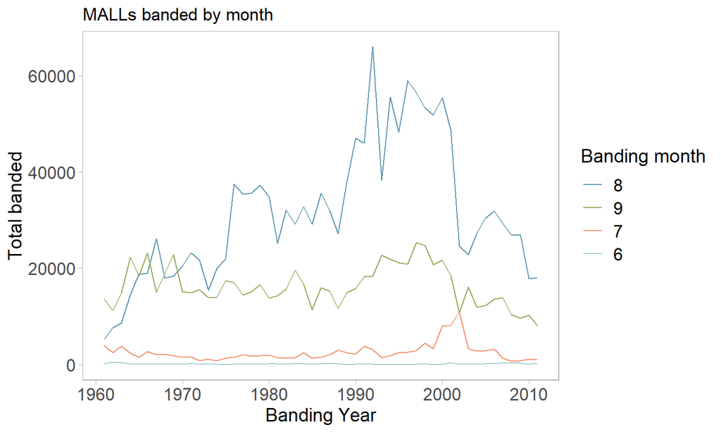

```r
final_bands %>%
  mutate(b_month = as.factor(b_month)) %>%
  group_by(b_year, b_month) %>%
  summarise(total_banded = sum(count_of_birds)) %>%
  ggplot(aes(x=b_year, y=total_banded, color=forcats::fct_reorder(b_month, total_banded, .desc = T))) +
  geom_line() + scale_color_manual(values = c(gmri_qual_extended[3],gmri_qual_extended[6],
                                              gmri_qual_extended[13],gmri_qual_extended[16])) + LGCtheme +
  labs(x="Banding Year", y="Total banded",
       title="MALLs banded by month", color="Banding month")
```

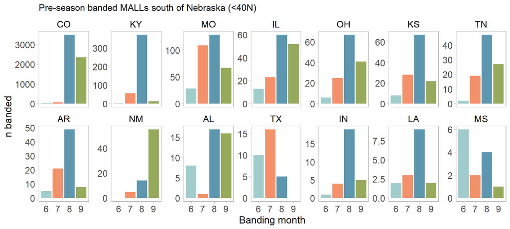

```r
final_bands %>%
  filter(gisb_lat<40) %>%
  group_by(b_region_abbrev,b_month) %>%
  summarise(n=n()) %>%
  ggplot(aes(x=b_month, y=n,fill=as.factor(b_month))) +
    facet_wrap(~forcats::fct_reorder(b_region_abbrev,n, .fun = sum, .desc = T), scales = "free_y", ncol = 7) +
  geom_bar(stat = "identity") + LGCtheme + theme(legend.position = "none") +
  scale_fill_manual(values = c(gmri_qual_extended[16],gmri_qual_extended[13],
                                              gmri_qual_extended[3],gmri_qual_extended[6])) +
  labs(x="Banding month", y="n banded", title="Pre-season banded MALLs south of Nebraska (<40N)")
```

## Spatial visualization

```r
banding_locs<-final_bands %>%
  group_by(gisb_lat,gisb_long) %>%
  summarise(n_bands=n())
```

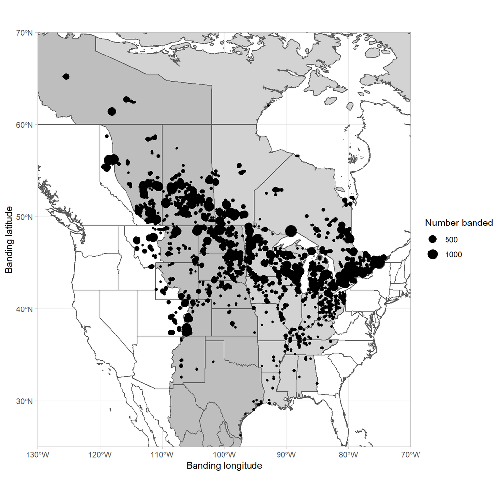

```r
ggplot(data = world) + geom_sf(fill="white") +
  geom_sf(data=states, fill=NA) +
  geom_sf(data=cent_flyway, fill="grey") +
  geom_sf(data=miss_flyway, fill="lightgrey") +
  geom_point(data=banding_locs, aes(x=gisb_long, y=gisb_lat, size=n_bands)) +
  coord_sf(xlim = c(-130, -70), ylim = c(25, 70), expand = FALSE) +
  labs(x="Banding longitude", y="Banding latitude", size="Number banded")
```

## Save datafile

```r
## write_csv(final_bands, here::here("proc_data","banding_data.csv"))
```